# EDA

## Cafe Sales - Exploratory Data Analysis

In the current notebook we will use the cleaned dataset produced in the previous one.

The objective is to apply different EDA techniques to extract valuable descriptive information from the data, explore trends and get some insight from visualizations.

This notebook is divided into three main themes: Sales Insights, Time-Based Patterns, and Customer Behavior.

```python
# Import libraries
import pandas as pd
import numpy as np
import matplotlib.pyplot as plt
import seaborn as sns
from matplotlib.colors import TwoSlopeNorm
import calendar
```

### 1. Load and Present Dataset

```python
# Fetch dataset and store it as data frame
df = pd.read_csv('clean_cafe_sales.csv')

df.head()
```

|  | Transaction ID | Item | Quantity | Price Per Unit | Total Spent | Payment Method | Location | Transaction Date | Year | Month Name | Week Day | Quarter | Unknown Values | Payment Category |
| --- | --- | --- | --- | --- | --- | --- | --- | --- | --- | --- | --- | --- | --- | --- |
| 0 | TXN_1961373 | Coffee | 2.0 | 2.0 | 4.0 | Credit Card | Takeaway | 2023-09-08 | 2023 | September | Friday | Q3-2023 | 0 | 0 |
| 1 | TXN_4977031 | Cake | 4.0 | 3.0 | 12.0 | Cash | In-store | 2023-05-16 | 2023 | May | Tuesday | Q2-2023 | 0 | 1 |
| 2 | TXN_4271903 | Cookie | 4.0 | 1.0 | 4.0 | Credit Card | In-store | 2023-07-19 | 2023 | July | Wednesday | Q3-2023 | 0 | 0 |
| 3 | TXN_7034554 | Salad | 2.0 | 5.0 | 10.0 | Unknown | Unknown | 2023-04-27 | 2023 | April | Thursday | Q2-2023 | 1 | -1 |
| 4 | TXN_3160411 | Coffee | 2.0 | 2.0 | 4.0 | Digital Wallet | In-store | 2023-06-11 | 2023 | June | Sunday | Q2-2023 | 0 | 2 |

```python
# Overlook shape and data types
df.info()
```

```
<class 'pandas.core.frame.DataFrame'>
RangeIndex: 9942 entries, 0 to 9941
Data columns (total 14 columns):
 #   Column            Non-Null Count  Dtype
---  ------            --------------  -----
 0   Transaction ID    9942 non-null   object
 1   Item              9942 non-null   object
 2   Quantity          9942 non-null   float64
 3   Price Per Unit    9942 non-null   float64
 4   Total Spent       9942 non-null   float64
 5   Payment Method    9942 non-null   object
 6   Location          9942 non-null   object
 7   Transaction Date  9942 non-null   object
 8   Year              9942 non-null   int64
 9   Month Name        9942 non-null   object
 10  Week Day          9942 non-null   object
 11  Quarter           9942 non-null   object
 12  Unknown Values    9942 non-null   int64
 13  Payment Category  9942 non-null   int64
dtypes: float64(3), int64(3), object(8)
memory usage: 1.1+ MB
```

```python
# Checking for nulls
df.isna().sum()
```

```
Transaction ID      0
Item                0
Quantity            0
Price Per Unit      0
Total Spent         0
Payment Method      0
Location            0
Transaction Date    0
Year                0
Month Name          0
Week Day            0
Quarter             0
Unknown Values      0
Payment Category    0
dtype: int64
```

```python
# Check duplicate values for Transaction IDs
df['Transaction ID'].duplicated().sum()
```

```
np.int64(0)
```

Based on the result, we can determine each transaction is unique.

### 2. Sales Insights

#### 2.1. What are the most frequently sold items?

Helps identify high-demand menu products, to manage inventory rotation and stock levels.

```python
# Rank Items by quantity sold
qty_rank = (
    df.groupby('Item')['Quantity']
    .sum()
    .reset_index()
    .sort_values(
        by = 'Quantity',
        ascending = False,
        ignore_index = True
    )
)
```

```python
qty_rank.head(10)
```

|  | Item | Quantity |
| --- | --- | --- |
| 0 | Juice | 6391.0 |
| 1 | Coffee | 3529.0 |
| 2 | Salad | 3463.0 |
| 3 | Cake | 3459.0 |
| 4 | Sandwich | 3411.0 |
| 5 | Smoothie | 3324.0 |
| 6 | Tea | 3286.0 |
| 7 | Cookie | 3219.0 |

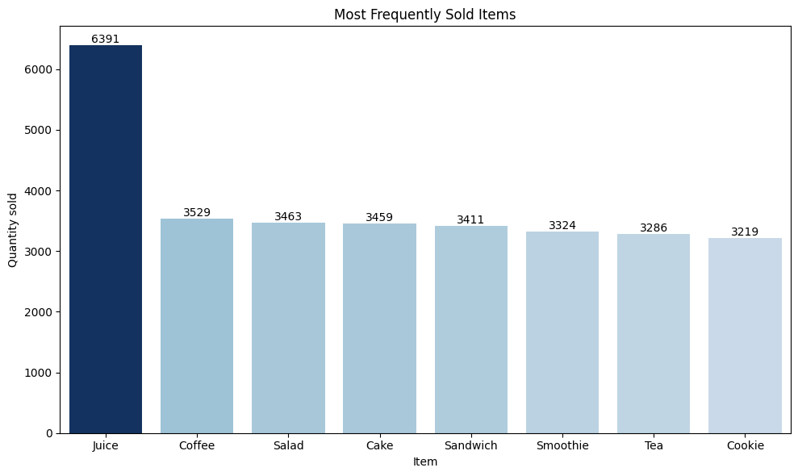

```python
# Visualize ranking

# 1. Normalize with a center point
norm = TwoSlopeNorm(
    vmin = qty_rank['Quantity'].mean() * 0.7,
    vcenter = qty_rank['Quantity'].mean(),
    vmax = qty_rank['Quantity'].max()
)

# Map to Blues colormap, as list
colors = [plt.cm.Blues(norm(val)) for val in qty_rank['Quantity']]

# 3. Plot

plt.figure(figsize = (10,6))

ax = sns.barplot(
    data = qty_rank,
    x = 'Item',
    y = 'Quantity',
    palette = colors,
    hue = 'Item',

)

for container in ax.containers:
    ax.bar_label(container)

plt.title('Most Frequently Sold Items')
plt.ylabel('Quantity sold')
plt.tight_layout()

plt.show()
```

#### 2.2. Which items generate the most total revenue?

Reveals which menu items are the most profitable overall based on the Total Spent column

```python
# Rank Items based on revenue
sales_rank = (
    df.groupby('Item')['Total Spent']
    .sum()
    .reset_index()
    .sort_values(
        by = 'Total Spent',
        ascending = False,
        ignore_index = True
    )
)
```

```python
sales_rank.head(10)
```

|  | Item | Total Spent |
| --- | --- | --- |
| 0 | Juice | 18962.5 |
| 1 | Salad | 17315.0 |
| 2 | Sandwich | 13644.0 |
| 3 | Smoothie | 13296.0 |
| 4 | Cake | 10377.0 |
| 5 | Coffee | 7058.0 |
| 6 | Tea | 4929.0 |
| 7 | Cookie | 3219.0 |

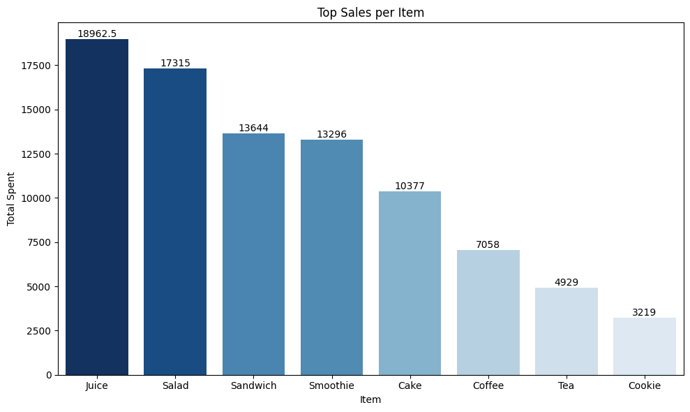

```python
# Visualize ranking

# 1. Normalize with a center point
norm = TwoSlopeNorm(
    vmin = 0,
    vcenter = sales_rank['Total Spent'].mean(),
    vmax = sales_rank['Total Spent'].max()
)

# Map to Blues colormap, as list
colors = [plt.cm.Blues(norm(val)) for val in sales_rank['Total Spent']]

# 3. Plot

plt.figure(figsize = (10,6))

ax = sns.barplot(
    data = sales_rank,
    x = 'Item',
    y = 'Total Spent',
    palette = colors,
    hue = 'Item',

)

for container in ax.containers:
    ax.bar_label(container)

plt.title('Top Sales per Item')
plt.ylabel('Total Spent')
plt.tight_layout()

plt.show()
```

#### 2.3. How does total revenue compare across different fulfillment locations?

Compares the performance of In-store vs. Takeaway sales to determine which channel drives more financial value for the café.

Note: Since we have alot of 'Unknown' location values, will take a subset of the dataset filtering those

```python
# Filter out unknown locations from the dataset
mask = df['Location'] != 'Unknown'

subset_loc = df[mask]

subset_loc.head(-1)
```

|  | Transaction ID | Item | Quantity | Price Per Unit | Total Spent | Payment Method | Location | Transaction Date | Year | Month Name | Week Day | Quarter | Unknown Values | Payment Category |
| --- | --- | --- | --- | --- | --- | --- | --- | --- | --- | --- | --- | --- | --- | --- |
| 0 | TXN_1961373 | Coffee | 2.0 | 2.0 | 4.0 | Credit Card | Takeaway | 2023-09-08 | 2023 | September | Friday | Q3-2023 | 0 | 0 |
| 1 | TXN_4977031 | Cake | 4.0 | 3.0 | 12.0 | Cash | In-store | 2023-05-16 | 2023 | May | Tuesday | Q2-2023 | 0 | 1 |
| 2 | TXN_4271903 | Cookie | 4.0 | 1.0 | 4.0 | Credit Card | In-store | 2023-07-19 | 2023 | July | Wednesday | Q3-2023 | 0 | 0 |
| 4 | TXN_3160411 | Coffee | 2.0 | 2.0 | 4.0 | Digital Wallet | In-store | 2023-06-11 | 2023 | June | Sunday | Q2-2023 | 0 | 2 |
| 6 | TXN_4433211 | Juice | 3.0 | 3.0 | 9.0 | Unknown | Takeaway | 2023-10-06 | 2023 | October | Friday | Q4-2023 | 1 | -1 |
| ... | ... | ... | ... | ... | ... | ... | ... | ... | ... | ... | ... | ... | ... | ... |
| 9924 | TXN_8567525 | Cookie | 2.0 | 1.0 | 2.0 | Unknown | Takeaway | 2023-12-30 | 2023 | December | Saturday | Q4-2023 | 1 | -1 |
| 9926 | TXN_3142496 | Smoothie | 1.0 | 4.0 | 4.0 | Cash | Takeaway | 2023-07-27 | 2023 | July | Thursday | Q3-2023 | 0 | 1 |
| 9928 | TXN_2858441 | Sandwich | 2.0 | 4.0 | 8.0 | Credit Card | In-store | 2023-12-14 | 2023 | December | Thursday | Q4-2023 | 0 | 0 |
| 9933 | TXN_3897619 | Sandwich | 3.0 | 4.0 | 12.0 | Cash | Takeaway | 2023-02-24 | 2023 | February | Friday | Q1-2023 | 0 | 1 |
| 9934 | TXN_2739140 | Smoothie | 4.0 | 4.0 | 16.0 | Unknown | In-store | 2023-07-05 | 2023 | July | Wednesday | Q3-2023 | 1 | -1 |

6001 rows × 14 columns

```python
# Summarize Items sales per location type
loc_sales = (
    subset_loc.groupby(['Item','Location'])['Total Spent']
    .sum()
    .reset_index()
    .sort_values(
        by = 'Total Spent',
        ascending = False,
        ignore_index = True
    )
)
```

```python
loc_sales.head(-1)
```

|  | Item | Location | Total Spent |
| --- | --- | --- | --- |
| 0 | Juice | In-store | 5752.0 |
| 1 | Salad | In-store | 5635.0 |
| 2 | Juice | Takeaway | 5626.5 |
| 3 | Salad | Takeaway | 5070.0 |
| 4 | Sandwich | In-store | 4496.0 |
| 5 | Sandwich | Takeaway | 4164.0 |
| 6 | Smoothie | In-store | 3812.0 |
| 7 | Smoothie | Takeaway | 3664.0 |
| 8 | Cake | Takeaway | 3132.0 |
| 9 | Cake | In-store | 2958.0 |
| 10 | Coffee | Takeaway | 2182.0 |
| 11 | Coffee | In-store | 1940.0 |
| 12 | Tea | Takeaway | 1521.0 |
| 13 | Tea | In-store | 1515.0 |
| 14 | Cookie | Takeaway | 1088.0 |

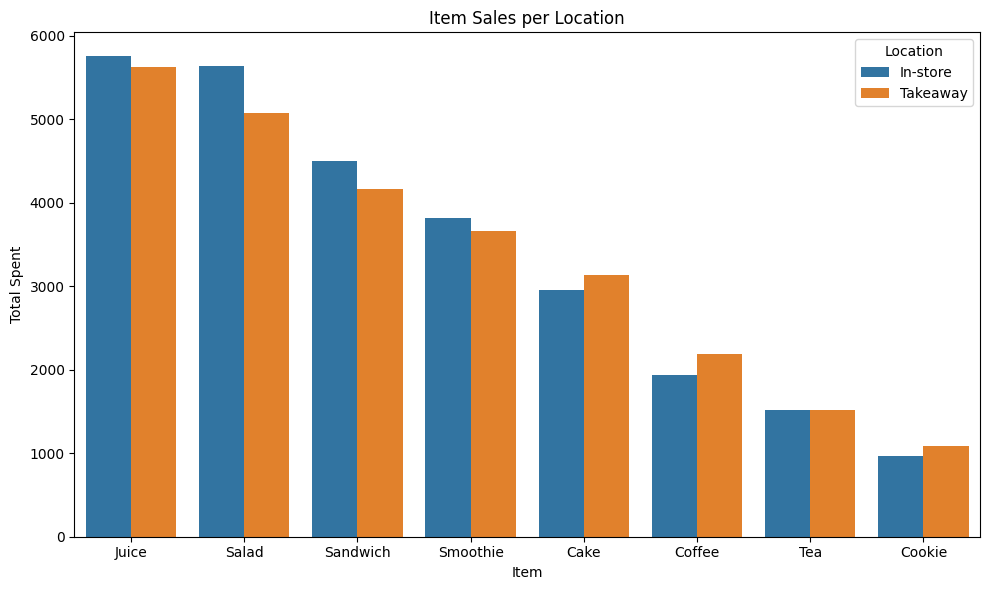

```python
# Visualize comparison

plt.figure(figsize = (10,6))

ax = sns.barplot(
    data = loc_sales,
    x = 'Item',
    y = 'Total Spent',
    hue = 'Location'

)

plt.title('Item Sales per Location')
plt.ylabel('Total Spent')
plt.tight_layout()

plt.show()
```

.

### 3. Time-Based Patterns

#### 3.1. Which days of the week have the highest sales activity?

Weekly customer habits, aiding in staff scheduling and daily prep planning.

Note: Here we will focus on number of transactions instead of sales because the information is needed for staff scheduling

```python
# Group transactions per week day
weekday_sales_count = (
    df.groupby('Week Day')['Transaction ID']
    .count()
    .reset_index()
)
```

```python
weekday_sales_count.head(7)
```

|  | Week Day | Transaction ID |
| --- | --- | --- |
| 0 | Friday | 1379 |
| 1 | Monday | 1375 |
| 2 | Saturday | 1347 |
| 3 | Sunday | 1833 |
| 4 | Thursday | 1373 |
| 5 | Tuesday | 1306 |
| 6 | Wednesday | 1329 |

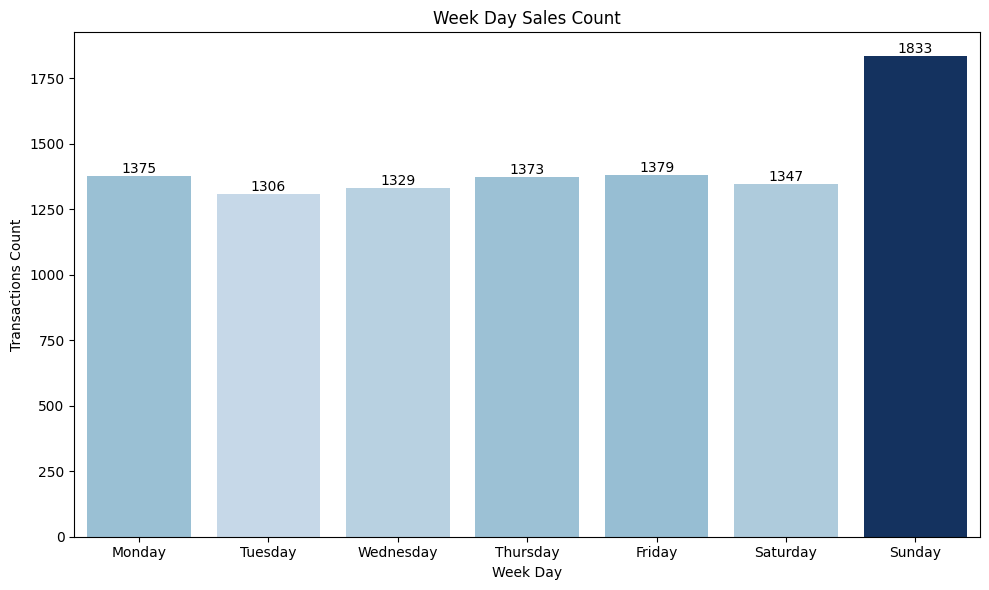

```python
# Visualize week day transactions

# 1. Normalize with a center point
norm = TwoSlopeNorm(
    vmin = weekday_sales_count['Transaction ID'].min() * 0.9,
    vcenter = weekday_sales_count['Transaction ID'].mean(),
    vmax = weekday_sales_count['Transaction ID'].max()
)

# 2. Map to Blues colormap, as list
colors = [plt.cm.Blues(norm(val)) for val in weekday_sales_count['Transaction ID']]

# 3. List week days orderly
days_ordered = ['Monday', 'Tuesday', 'Wednesday', 'Thursday', 'Friday', 'Saturday', 'Sunday']

# 4. Plot
plt.figure(figsize = (10,6))

ax = sns.barplot(
    data = weekday_sales_count,
    x = 'Week Day',
    y = 'Transaction ID',
    palette = colors,
    hue = 'Week Day',
    order = days_ordered
)

for container in ax.containers:
    ax.bar_label(container)

plt.title('Week Day Sales Count')
plt.ylabel('Transactions Count')
plt.tight_layout()

plt.show()
```

#### 3.2. How do monthly sales compare?

Evaluates the Month Name column to spot seasonal trends, holiday shifts, or baseline demand changes throughout the year.

```python
# Group sales per month
monthly_sales = (
    df.groupby('Month Name')['Total Spent']
    .sum()
    .reset_index()
)
```

```python
monthly_sales.head()
```

|  | Month Name | Total Spent |
| --- | --- | --- |
| 0 | April | 7168.0 |
| 1 | August | 7049.5 |
| 2 | December | 7153.0 |
| 3 | February | 6626.0 |
| 4 | January | 7219.0 |

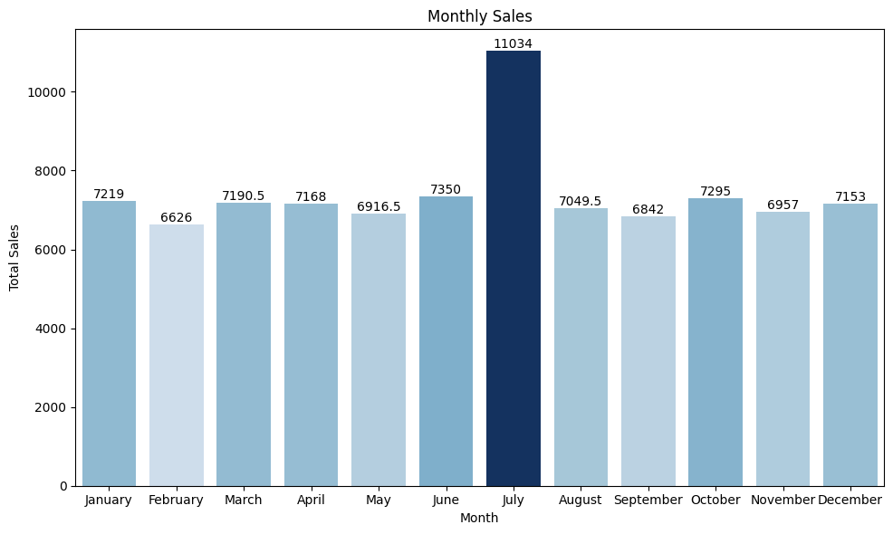

```python
# Visualize monthly sales

# 1. Normalize with a center point
norm = TwoSlopeNorm(
    vmin = monthly_sales['Total Spent'].min() * 0.9,
    vcenter = monthly_sales['Total Spent'].mean(),
    vmax = monthly_sales['Total Spent'].max()
)

# 2. Map to Blues colormap, as list
colors = [plt.cm.Blues(norm(val)) for val in monthly_sales['Total Spent']]

# 3. List months orderly
months = list(calendar.month_name)[1:]

# 4. Plot
plt.figure(figsize = (10,6))

ax = sns.barplot(
    data = monthly_sales,
    x = 'Month Name',
    y = 'Total Spent',
    palette = colors,
    hue = 'Month Name',
    order = months
)

for container in ax.containers:
    ax.bar_label(container)

plt.title('Monthly Sales')
plt.xlabel('Month')
plt.ylabel('Total Sales')
plt.tight_layout()

plt.show()
```

#### 3.3. How do sales volume vary across fiscal quarters?

Groups performance by quarters to provide a macro-level business health summary for stakeholders.

```python
quarter_sales = (
    df.groupby('Quarter')['Total Spent']
    .sum()
    .reset_index()
)
```

```python
quarter_sales
```

|  | Quarter | Total Spent |
| --- | --- | --- |
| 0 | Q1-2023 | 21035.5 |
| 1 | Q2-2023 | 21434.5 |
| 2 | Q3-2023 | 24925.5 |
| 3 | Q4-2023 | 21405.0 |

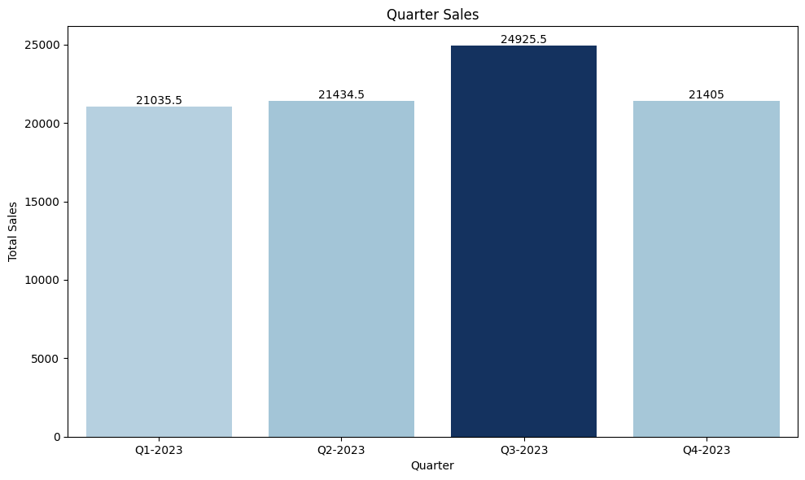

```python
# Visualize monthly sales

# 1. Normalize with a center point
norm = TwoSlopeNorm(
    vmin = quarter_sales['Total Spent'].min() * 0.9,
    vcenter = quarter_sales['Total Spent'].mean(),
    vmax = quarter_sales['Total Spent'].max()
)

# 2. Map to Blues colormap, as list
colors = [plt.cm.Blues(norm(val)) for val in quarter_sales['Total Spent']]

# 3. Plot
plt.figure(figsize = (10,6))

ax = sns.barplot(
    data = quarter_sales,
    x = 'Quarter',
    y = 'Total Spent',
    palette = colors,
    hue = 'Quarter'
)

for container in ax.containers:
    ax.bar_label(container)

plt.title('Quarter Sales')
plt.ylabel('Total Sales')
plt.tight_layout()

plt.show()
```

### 4. Customer Behavior

#### 4.1. What are the most commonly used payment methods?

Measures preferences across Credit Card, Cash, and Digital Wallet transactions to inform payment provider partnerships and point-of-sale operational needs.

```python
# Check unique payment methods
df['Payment Method'].value_counts()
```

```
Payment Method
Unknown           3158
Digital Wallet    2280
Credit Card       2260
Cash              2244
Name: count, dtype: int64
```

```python
# Subset of cases with known payment methods, -1 is code for unknown
mask = df['Payment Category'] != -1

subset = df[mask]

subset.head(-1)
```

|  | Transaction ID | Item | Quantity | Price Per Unit | Total Spent | Payment Method | Location | Transaction Date | Year | Month Name | Week Day | Quarter | Unknown Values | Payment Category |
| --- | --- | --- | --- | --- | --- | --- | --- | --- | --- | --- | --- | --- | --- | --- |
| 0 | TXN_1961373 | Coffee | 2.0 | 2.0 | 4.0 | Credit Card | Takeaway | 2023-09-08 | 2023 | September | Friday | Q3-2023 | 0 | 0 |
| 1 | TXN_4977031 | Cake | 4.0 | 3.0 | 12.0 | Cash | In-store | 2023-05-16 | 2023 | May | Tuesday | Q2-2023 | 0 | 1 |
| 2 | TXN_4271903 | Cookie | 4.0 | 1.0 | 4.0 | Credit Card | In-store | 2023-07-19 | 2023 | July | Wednesday | Q3-2023 | 0 | 0 |
| 4 | TXN_3160411 | Coffee | 2.0 | 2.0 | 4.0 | Digital Wallet | In-store | 2023-06-11 | 2023 | June | Sunday | Q2-2023 | 0 | 2 |
| 5 | TXN_2602893 | Smoothie | 5.0 | 4.0 | 20.0 | Credit Card | Unknown | 2023-03-31 | 2023 | March | Friday | Q1-2023 | 1 | 0 |
| ... | ... | ... | ... | ... | ... | ... | ... | ... | ... | ... | ... | ... | ... | ... |
| 9933 | TXN_3897619 | Sandwich | 3.0 | 4.0 | 12.0 | Cash | Takeaway | 2023-02-24 | 2023 | February | Friday | Q1-2023 | 0 | 1 |
| 9935 | TXN_4766549 | Smoothie | 2.0 | 4.0 | 8.0 | Cash | Unknown | 2023-10-20 | 2023 | October | Friday | Q4-2023 | 1 | 1 |
| 9938 | TXN_9659401 | Juice | 3.0 | 1.0 | 3.0 | Digital Wallet | Unknown | 2023-06-02 | 2023 | June | Friday | Q2-2023 | 1 | 2 |
| 9939 | TXN_5255387 | Coffee | 4.0 | 2.0 | 8.0 | Digital Wallet | Unknown | 2023-03-02 | 2023 | March | Thursday | Q1-2023 | 1 | 2 |
| 9940 | TXN_7695629 | Cookie | 3.0 | 1.0 | 3.0 | Digital Wallet | Unknown | 2023-12-02 | 2023 | December | Saturday | Q4-2023 | 1 | 2 |

6783 rows × 14 columns

```python
# Count transactions per payment method
payment_rank = (
    subset.groupby('Payment Method')['Transaction ID']
    .count()
    .reset_index()
    .sort_values(
        by = 'Transaction ID',
        ascending = False,
        ignore_index = True
    )
)
```

```python
payment_rank.head()
```

|  | Payment Method | Transaction ID |
| --- | --- | --- |
| 0 | Digital Wallet | 2280 |
| 1 | Credit Card | 2260 |
| 2 | Cash | 2244 |

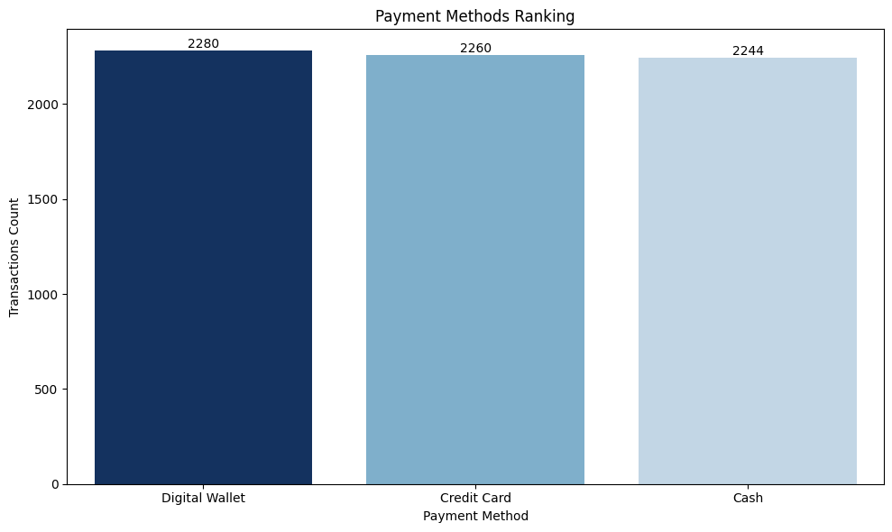

```python
# Visualize payment method ranking

# 1. Normalize with a center point
norm = TwoSlopeNorm(
    vmin = payment_rank['Transaction ID'].min() * 0.99,
    vcenter = payment_rank['Transaction ID'].mean(),
    vmax = payment_rank['Transaction ID'].max()
)

# 2. Map to Blues colormap, as list
colors = [plt.cm.Blues(norm(val)) for val in payment_rank['Transaction ID']]

# 3. Plot
plt.figure(figsize = (10,6))

ax = sns.barplot(
    data = payment_rank,
    x = 'Payment Method',
    y = 'Transaction ID',
    palette = colors,
    hue = 'Payment Method'
)

for container in ax.containers:
    ax.bar_label(container)

plt.title('Payment Methods Ranking')
plt.ylabel('Transactions Count')
plt.tight_layout()

plt.show()
```

#### 4.2. Do customers spend differently depending on their payment method?

```python
# Group sales per payment method
sales_per_payment = (
    subset.groupby('Payment Method')['Total Spent']
    .sum()
    .reset_index()
    .sort_values(
        by = 'Total Spent',
        ascending = False,
        ignore_index = True
    )
)
```

```python
sales_per_payment.head()
```

|  | Payment Method | Total Spent |
| --- | --- | --- |
| 0 | Credit Card | 20386.5 |
| 1 | Digital Wallet | 20362.5 |
| 2 | Cash | 20340.5 |

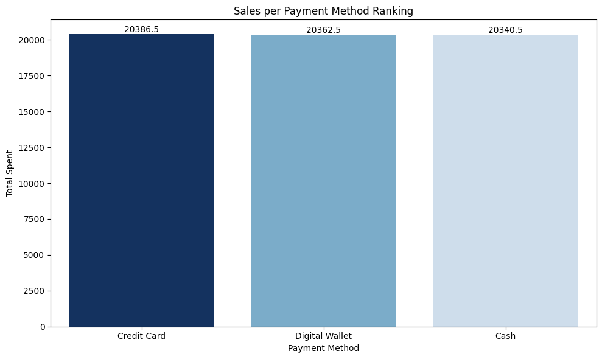

```python
# Visualize sales per payment method ranking

# 1. Normalize with a center point
norm = TwoSlopeNorm(
    vmin = sales_per_payment['Total Spent'].min() * 0.999,
    vcenter = sales_per_payment['Total Spent'].mean(),
    vmax = sales_per_payment['Total Spent'].max()
)

# 2. Map to Blues colormap, as list
colors = [plt.cm.Blues(norm(val)) for val in sales_per_payment['Total Spent']]

# 3. Plot
plt.figure(figsize = (10,6))

ax = sns.barplot(
    data = sales_per_payment,
    x = 'Payment Method',
    y = 'Total Spent',
    palette = colors,
    hue = 'Payment Method'
)

for container in ax.containers:
    ax.bar_label(container)

plt.title('Sales per Payment Method Ranking')
plt.ylabel('Total Spent')
plt.tight_layout()

plt.show()
```

Spent is similar in the 3 different methods

#### 4.3. How does the choice of payment method vary between In-store and Takeaway locations?

Cross-references Payment Method with Location to see if customer payment preferences dynamically change depending on how they order.

```python
# Filter case with only known locations and payment methods
mask = df['Unknown Values'] == 0

subset = df[mask]

subset.head()
```

|  | Transaction ID | Item | Quantity | Price Per Unit | Total Spent | Payment Method | Location | Transaction Date | Year | Month Name | Week Day | Quarter | Unknown Values | Payment Category |
| --- | --- | --- | --- | --- | --- | --- | --- | --- | --- | --- | --- | --- | --- | --- |
| 0 | TXN_1961373 | Coffee | 2.0 | 2.0 | 4.0 | Credit Card | Takeaway | 2023-09-08 | 2023 | September | Friday | Q3-2023 | 0 | 0 |
| 1 | TXN_4977031 | Cake | 4.0 | 3.0 | 12.0 | Cash | In-store | 2023-05-16 | 2023 | May | Tuesday | Q2-2023 | 0 | 1 |
| 2 | TXN_4271903 | Cookie | 4.0 | 1.0 | 4.0 | Credit Card | In-store | 2023-07-19 | 2023 | July | Wednesday | Q3-2023 | 0 | 0 |
| 4 | TXN_3160411 | Coffee | 2.0 | 2.0 | 4.0 | Digital Wallet | In-store | 2023-06-11 | 2023 | June | Sunday | Q2-2023 | 0 | 2 |
| 10 | TXN_2548360 | Salad | 5.0 | 5.0 | 25.0 | Cash | Takeaway | 2023-11-07 | 2023 | November | Tuesday | Q4-2023 | 0 | 1 |

```python
# Correlation matrix for location vs payment method
location_payment_matrix = subset.pivot_table(
    index = 'Payment Method',
    columns = 'Location',
    values = 'Transaction ID',
    aggfunc = 'count'
)
```

```python
location_payment_matrix
```

| Location Payment Method | In-store | Takeaway |
| --- | --- | --- |
| Cash | 697 | 659 |
| Credit Card | 677 | 666 |
| Digital Wallet | 691 | 739 |

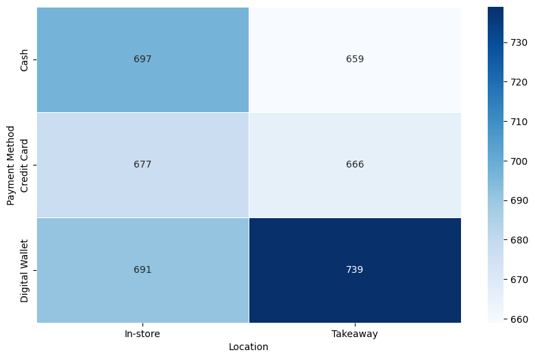

```python
# Visualize matrix

f, ax = plt.subplots(figsize=(10, 6))

sns.heatmap(
    location_payment_matrix,
    annot=True,
    fmt="d",
    linewidths=.5,
    ax=ax,
    cmap = "Blues"
)

plt.show()
```